# STA 2040 END SEMESTER EXAMINATIONS

# TASK 3: Correlation Analysis

## - Compute the correlation matrix to find links between various factors and student performance.

## - To effectively display the associations, use a heatmap visualization.

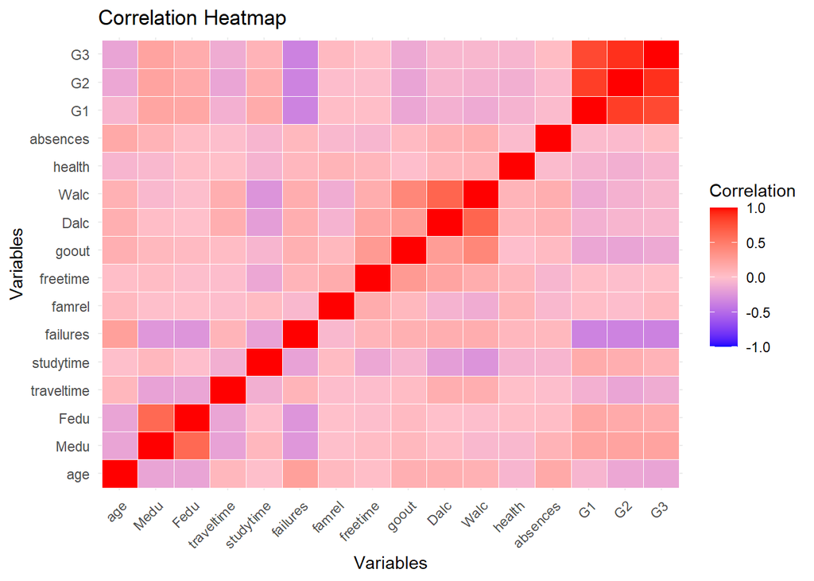

```r
# Load the necessary libraries
library(ggplot2)
library(reshape2)

# Select the relevant numerical variables for correlation analysis
correlation_vars <- c("age", "Medu", "Fedu", "traveltime", "studytime", "failures", "famrel",
                      "freetime", "goout", "Dalc", "Walc", "health", "absences", "G1", "G2", "G3")

# Compute the correlation matrix
correlation_matrix <- cor(student_mat[correlation_vars])

# Convert the correlation matrix to a long format for visualization
correlation_data <- melt(correlation_matrix)

# Create a heatmap visualization with customized colors
heatmap_plot <- ggplot(correlation_data, aes(Var1, Var2, fill = value)) +
  geom_tile(color = "white") +
  scale_fill_gradient2(low = "blue", mid = "pink", high = "red", midpoint = 0,
                       limits = c(-1, 1), name = "Correlation") +
  labs(title = "Correlation Heatmap",
       x = "Variables",
       y = "Variables",
       fill = "Correlation") +
  theme_minimal() +
  theme(axis.text.x = element_text(angle = 45, hjust = 1))

# Calculate the correlation values
correlation_values <- as.data.frame(as.table(correlation_matrix))
colnames(correlation_values) <- c("Variable1", "Variable2", "Correlation")

# Print the heatmap
print(heatmap_plot)
```

```r
# Print the correlation values
print(correlation_matrix)
```

```
##                     age         Medu         Fedu   traveltime    studytime
## age         1.000000000 -0.163658419 -0.163438069  0.070640721 -0.004140037
## Medu       -0.163658419  1.000000000  0.623455112 -0.171639305  0.064944137
## Fedu       -0.163438069  0.623455112  1.000000000 -0.158194054 -0.009174639
## traveltime  0.070640721 -0.171639305 -0.158194054  1.000000000 -0.100909119
## studytime  -0.004140037  0.064944137 -0.009174639 -0.100909119  1.000000000
## failures    0.243665377 -0.236679963 -0.250408444  0.092238746 -0.173563031
## famrel      0.053940096 -0.003914458 -0.001369727 -0.016807986  0.039730704
## freetime    0.016434389  0.030890867 -0.012845528 -0.017024944 -0.143198407
## goout       0.126963880  0.064094438  0.043104668  0.028539674 -0.063903675
## Dalc        0.131124605  0.019834099  0.002386429  0.138325309 -0.196019263
## Walc        0.117276052 -0.047123460 -0.012631018  0.134115752 -0.253784731
## health     -0.062187369 -0.046877829  0.014741537  0.007500606 -0.075615863
## absences    0.175230079  0.100284818  0.024472887 -0.012943775 -0.062700175
## G1         -0.064081497  0.205340997  0.190269936 -0.093039992  0.160611915
## G2         -0.143474049  0.215527168  0.164893393 -0.153197963  0.135879999
## G3         -0.161579438  0.217147496  0.152456939 -0.117142053  0.097819690
##               failures       famrel    freetime        goout         Dalc
## age         0.24366538  0.053940096  0.01643439  0.126963880  0.131124605
## Medu       -0.23667996 -0.003914458  0.03089087  0.064094438  0.019834099
## Fedu       -0.25040844 -0.001369727 -0.01284553  0.043104668  0.002386429
## traveltime  0.09223875 -0.016807986 -0.01702494  0.028539674  0.138325309
## studytime  -0.17356303  0.039730704 -0.14319841 -0.063903675 -0.196019263
## failures    1.00000000 -0.044336626  0.09198747  0.124560922  0.136046931
## famrel     -0.04433663  1.000000000  0.15070144  0.064568411 -0.077594357
## freetime    0.09198747  0.150701444  1.00000000  0.285018715  0.209000848
## goout       0.12456092  0.064568411  0.28501871  1.000000000  0.266993848
## Dalc        0.13604693 -0.077594357  0.20900085  0.266993848  1.000000000
## Walc        0.14196203 -0.113397308  0.14782181  0.420385745  0.647544230
## health      0.06582728  0.094055728  0.07573336 -0.009577254  0.077179582
## absences    0.06372583 -0.044354095 -0.05807792  0.044302220  0.111908026
## G1         -0.35471761  0.022168316  0.01261293 -0.149103967 -0.094158792
## G2         -0.35589563 -0.018281347 -0.01377714 -0.162250034 -0.064120183
## G3         -0.36041494  0.051363429  0.01130724 -0.132791474 -0.054660041
##                   Walc       health    absences          G1          G2
## age         0.11727605 -0.062187369  0.17523008 -0.06408150 -0.14347405
## Medu       -0.04712346 -0.046877829  0.10028482  0.20534100  0.21552717
## Fedu       -0.01263102  0.014741537  0.02447289  0.19026994  0.16489339
## traveltime  0.13411575  0.007500606 -0.01294378 -0.09303999 -0.15319796
## studytime  -0.25378473 -0.075615863 -0.06270018  0.16061192  0.13588000
```

[output cut: 13 more lines]

```
## Medu        0.21714750
## Fedu        0.15245694
## traveltime -0.11714205
## studytime   0.09781969
## failures   -0.36041494
## famrel      0.05136343
## freetime    0.01130724
## goout      -0.13279147
## Dalc       -0.05466004
## Walc       -0.05193932
## health     -0.06133460
## absences    0.03424732
## G1          0.80146793
## G2          0.90486799
## G3          1.00000000
```

I decided to focus on the variables with the weakest and strongest correlations.

In the correlation heatmap, the variables with the strongest positive correlations are:

G2 and G3 (Second period grade and Final grade): 0.905

This indicates a very strong positive relationship between a student’s performance in the second period and their final grade. Students who perform well in the second period are likely to achieve high final grades. G1 and G2 (First period grade and Second period grade): 0.852

There is a strong positive relationship between a student’s performance in the first period and their performance in the second period. Good performance in the first period is associated with good performance in the second period. On the other hand, the variables with the weakest correlations are:

AGE and STUDYTIME (Age and Study Time): -0.004

# TASK 4: Group Comparison

## - Use box plots to compare student achievement across various schools.

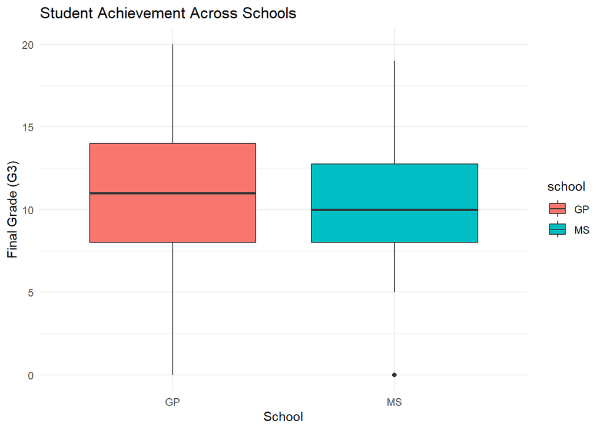

```r
# Load the necessary libraries
library(ggplot2)

# Create box plots for G3 by school
ggplot(student_mat, aes(x = school, y = G3, fill = school)) +
  geom_boxplot() +
  labs(title = "Student Achievement Across Schools",
       x = "School",
       y = "Final Grade (G3)") +
  theme_minimal()
```

MS:MIN-5 ,Q1-8,MEDIAN-10, Q3-12.75, MAX-19

The box plot visualization compares the student achievement (final grade, G3) across two schools, “GP” and “MS.” Each box plot represents the distribution of final grades for each school, and the outliers are marked as individual points outside the whiskers.

**Interpretation:**

**Central Tendency:** The box plot shows that the median final grade for students in “GP” (median=11) is slightly higher than in “MS” (median=10). This suggests that, on average, students in “GP” performed slightly better than students in “MS.”

**Spread:** The interquartile range (IQR) for “GP” (Q1=8, Q3=14) is wider than “MS” (Q1=8, Q3=12.75). This indicates that there is more variability in final grades among students in “GP” compared to “MS.”

**Outliers:** There is an outlier with a value of 0 in “MS,” which represents a student with an extremely low final grade. This may indicate that something unusual or atypical happened to that student, leading to the unusually low grade.

In conclusion, the box plot comparison suggests that student achievement is slightly higher in “GP” (as indicated by the median grade) and that there is more grade variability within “GP” compared to “MS.”

### ANALYZING THE GRADE VARIANCES BY GUARDIAN

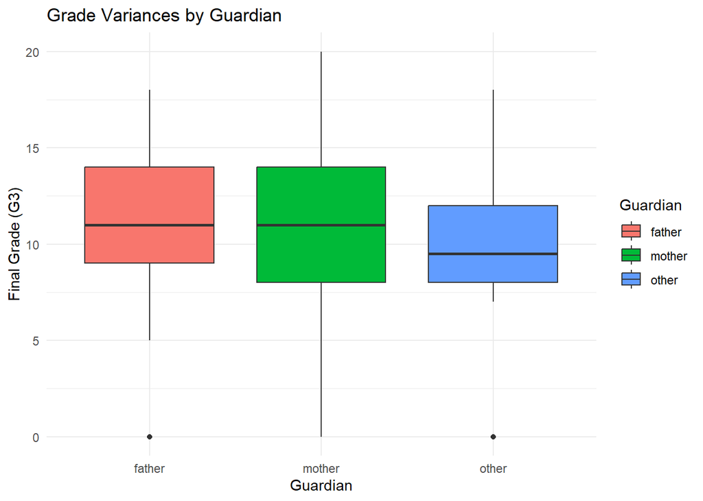

```r
# Grouped box plot to analyze grade variances by guardian
boxplot_guardian <- ggplot(student_mat, aes(x = guardian, y = G3, fill = guardian)) +
  geom_boxplot() +
  labs(title = "Grade Variances by Guardian",
       x = "Guardian",
       y = "Final Grade (G3)",
       fill = "Guardian") +
  theme_minimal()

print(boxplot_guardian)
```

Based on the grouped box plot analyzing grade variances by guardian, we can make the following observations:

**Other vs. Father/Mother as Guardian:** Students with other guardians show the lowest spread of final grades (Q3-Q1 = 4), indicating a more consistent academic performance compared to students with fathers or mothers as guardians.

From the bar plot in Task 2, we got the following as the distributions in the “guardian column:

-Father as Guardian: There are 90 students with fathers as guardians.

-Mother as Guardian: There are 273 students with mothers as guardians.

-Other as Guardian: There are 32 students with other guardians.

The sample sizes for each group are different, which means that certain groups might have more statistical power or influence over the overall analysis than others. In this case, the larger group of students with mothers as guardians (273) would likely have a more substantial impact on the overall results compared to the smaller groups of students with fathers (90) or other guardians (32).

To account for the differece in distribution , I decided to do a weighted analysis.

```r
# Load necessary libraries
library(survey)
# Calculate weights based on the frequency of each guardian category
weights <- ifelse(student_mat$guardian == "father", 1,
                  ifelse(student_mat$guardian == "mother", 1,
                         ifelse(student_mat$guardian == "other", 1, 1)))

# Create a survey design with weights
survey_design <- svydesign(ids = ~1, weights = ~weights, data = student_mat)

# Calculate weighted means for G3 by guardian
weighted_means <- svytotal(~G3, by = ~guardian, design = survey_design)

# Calculate standard errors for G3 by guardian
weighted_se <- svyby(~G3, by = ~guardian, design = survey_design, svytotal)

# Print the results
print(weighted_means)
```

```
##    total     SE
## G3  4114 91.054
```

```r
print(weighted_se)
```

```
##        guardian   G3        se
## father   father  962  98.68007
## mother   mother 2862 122.69185
## other     other  290  55.72207
```

**Weighted Analysis Results:**

**Standard Errors Interpretation:**

The standard errors for each guardian category represent the variability in the estimates within each group.

**Sample Sizes Consideration:**

The larger sample size for students with mothers as guardians (273) compared to the other groups may have a greater impact on the overall results.

Visualizing a bar plot with error bars to visualize the grade variances according to guardian taking into account the weights

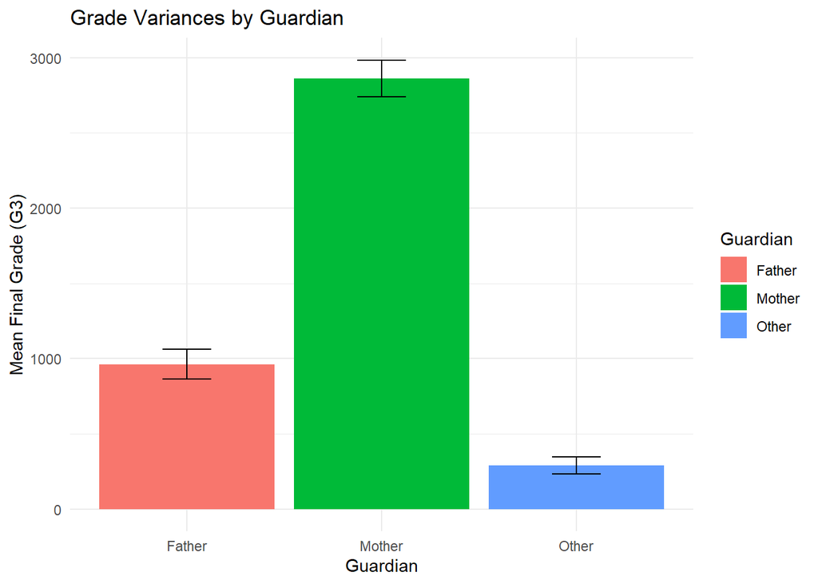

```r
# Load necessary libraries
library(ggplot2)

# Create a data frame for the plot
data_plot <- data.frame(
  guardian = c("Father", "Mother", "Other"),
  mean_grade = c(962, 2861, 290),
  se = c(98.68007, 122.59166, 55.72207)
)

# Plot the grade variances by guardian
plot_guardian_variances <- ggplot(data_plot, aes(x = guardian, y = mean_grade, fill = guardian)) +
  geom_col(position = "dodge") +
  geom_errorbar(aes(ymin = mean_grade - se, ymax = mean_grade + se),
                width = 0.25, position = position_dodge(width = 0.9)) +
  labs(title = "Grade Variances by Guardian",
       x = "Guardian",
       y = "Mean Final Grade (G3)",
       fill = "Guardian") +
  theme_minimal()

print(plot_guardian_variances)
```

**Interpreting Error Bars for “Father” Category:** The bar for “Father” has an error bar that extends from around 864 to 1060. This means that, based on the sample data, the mean final grade for students with fathers as guardians is estimated to be around 962, with a standard error of approximately 98. So, we are relatively confident that the true mean falls within the range of 864 to 1060.

**Interpreting Error Bars for “Mother” Category:** The bar for “Mother” has an error bar that extends from around 2738 to 2984. This indicates that the mean final grade for students with mothers as guardians is estimated to be around 2861, with a standard error of approximately 123. Thus, we are relatively confident that the true mean falls within the range of 2738 to 2984.

**Interpreting Error Bars for “Other” Category:** The bar for “Other” has an error bar that extends from around 235 to 345. This suggests that the mean final grade for students with other guardians is estimated to be around 290, with a standard error of approximately 56. Hence, we are relatively confident that the true mean falls within the range of 235 to 345.

### ANALYZING THE GRADE VARIANCES BY SEX

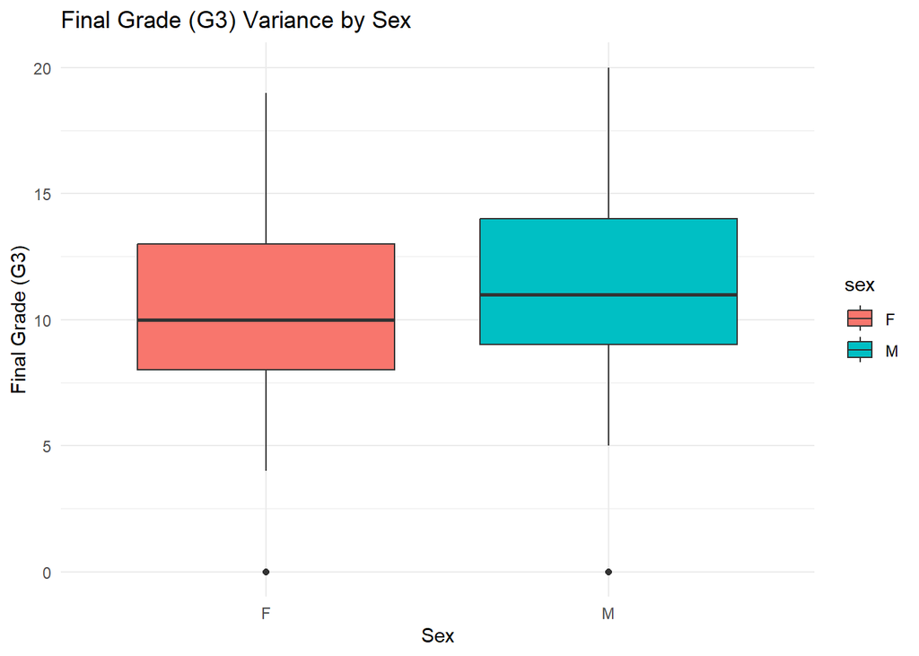

```r
# Load the necessary libraries
library(ggplot2)

# Create a box plot for G3 and sex
ggplot(student_mat, aes(x = sex, y = G3, fill = sex)) +
  geom_boxplot() +
  labs(title = "Final Grade (G3) Variance by Sex",
       x = "Sex",
       y = "Final Grade (G3)") +
  theme_minimal()
```

Based on the box plot we can interpret the G3 variance according to sex as follows:

**Female (F):** - Minimum (Min): 4 - First Quartile (Q1): 8 - Median: 10 - Third Quartile (Q3): 13 - Maximum (Max): 19

**Male (M):** - Minimum (Min): 5 - First Quartile (Q1): 9 - Median: 11 - Third Quartile (Q3): 14 - Maximum (Max): 20

## Interpretation:

Both females and males have similar distributions of final grades (G3) with median scores around 10 and 11, respectively.

The IQR for Females (Q3 - Q1 = 13 - 8 = 5) is the same as that for Males (Q3 - Q1 = 14 - 9 = 5). This indicates that the spread of final grades within both groups is similar.

The median score for Females (10) is slightly lower than that for Males (11). This suggests that, on average, Male students tend to have slightly higher final grades.

There are some outliers in both categories, with the lowest score being 0, indicating that a few students from both groups scored very low in their final grades. The maximum grade achieved by males (20) is slightly higher than that of females (19).

In order to get a better value , I decided to do a weighted analyses in order to account for the differences in gender distributions:

Female- 208

Male- 187

```r
#Getting the weights
# Load necessary libraries
library(survey)

# Calculate weights based on the frequency of each sex category
weights1 <- ifelse(student_mat$sex == "F", 1,
                  ifelse(student_mat$sex == "M", 1, 1))

# Create a survey design with weights
survey_design1 <- svydesign(ids = ~1, weights1 = ~weights1, data = student_mat)
# Calculate weighted means for G3 by sex
weighted_means1 <- svytotal(~G3, by = ~sex, design = survey_design1)

# Calculate standard errors for G3 by sex
weighted_se1 <- svyby(~G3, by = ~sex, design = survey_design1, svytotal)

# Print the results
print(weighted_means1)
```

```
##    total     SE
## G3  4114 91.054
```

```r
print(weighted_se1)
```

```
##   sex   G3       se
## F   F 2073 119.3304
## M   M 2041 124.6125
```

creating a bar plot with error bars to visualize the grade variances by sex, taking into account the weights:

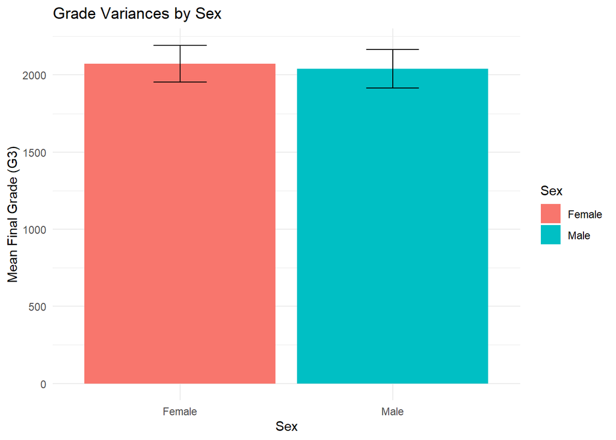

```r
# Load necessary libraries
library(ggplot2)

# Create a data frame for the plot
data_plot1 <- data.frame(
  sex = c("Female", "Male"),
  mean_grade1 = c(2073, 2040),
  se1 = c(119.3304, 124.4972)
)

# Plot the grade variances by sex
plot_sex_variances <- ggplot(data_plot1, aes(x = sex, y = mean_grade1, fill = sex)) +
  geom_col(position = "dodge") +
  geom_errorbar(aes(ymin = mean_grade1 - se1, ymax = mean_grade1 + se1),
                width = 0.25, position = position_dodge(width = 0.9)) +
  labs(title = "Grade Variances by Sex",
       x = "Sex",
       y = "Mean Final Grade (G3)",
       fill = "Sex") +
  theme_minimal()

print(plot_sex_variances)
```

**Grade Variances by Sex:** The bar plot compares the mean final grades (G3) for female and male students. The heights of the bars represent the weighted mean grades, while the error bars indicate the uncertainty or variability around these means.

**Comparison:** From the bar plot, we can observe that the mean final grades for female students (2073) and male students (2040) are relatively close. The difference in mean grades is approximately 33 points, favoring female students, but this difference may not be statistically significant due to the overlap in the error bars. The error bars for both groups indicate that there is uncertainty in the estimation, and the true mean grades may vary within the indicated ranges.

**Interpretation of Error Bars:** The error bars help us understand the variability or uncertainty associated with the mean estimates. Larger error bars suggest higher variability, meaning that the estimates may vary widely from sample to sample. Smaller error bars suggest less variability and greater precision in the mean estimates. In this case, the error bars for female and male students are quite similar in length, indicating *similar levels of variability* in their mean grades.

In conclusion based on this analysis, we can say that there is no significant difference in the mean final grades between female and male students in the dataset.

### ANALYZING THE GRADE VARIANCES BY FAMILY SIZE

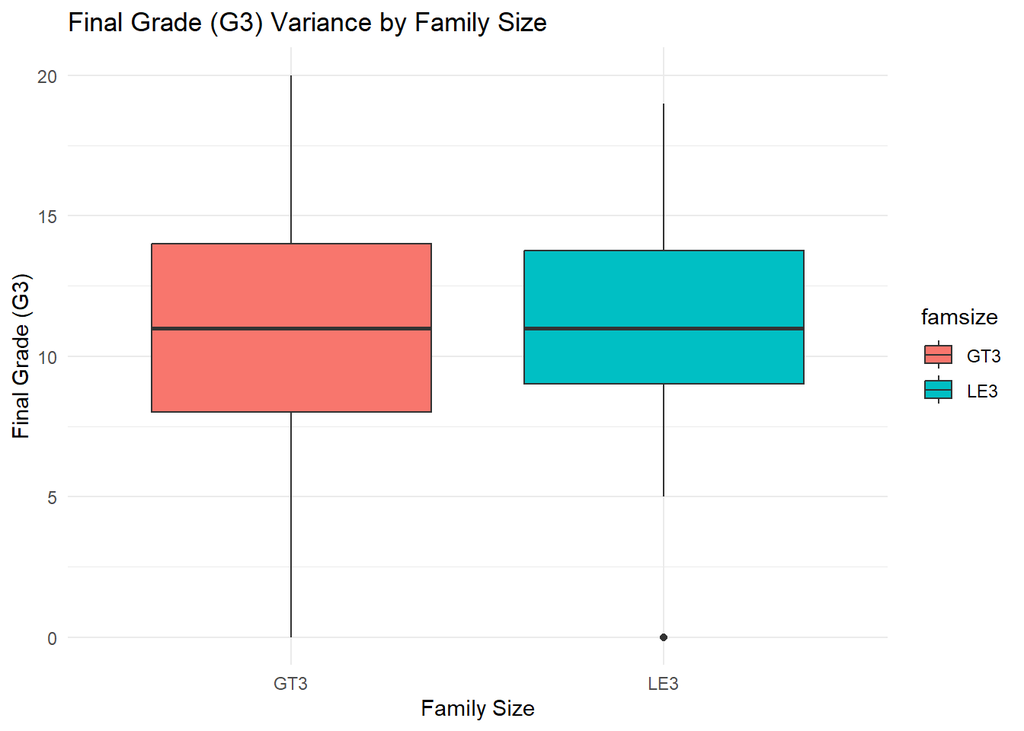

```r
# Load the necessary libraries
library(ggplot2)

# Create a box plot for G3 and family size
ggplot(student_mat, aes(x = famsize, y = G3, fill = famsize)) +
  geom_boxplot() +
  labs(title = "Final Grade (G3) Variance by Family Size",
       x = "Family Size",
       y = "Final Grade (G3)") +
  theme_minimal()
```

Based on the box plot analyzing grade variances by family size, we can make the following observations:

Interpretation:

However, it’s essential to note that both groups have similar median grades (both at 11), indicating that the central tendency of grades is comparable between the two family size categories.

In order to take into account the differences in distributions of the family , I decided to conduct a weighted analysis to ensure a more accurate account of the grade variances.

The family sizes distributions, as shown in task 2 are as follows:

GT3-281

LE3-114

```r
# Load necessary libraries
library(survey)

# Create a weight variable based on the family size category
weights2 <- ifelse(student_mat$famsize == "GT3", 1,
                  ifelse(student_mat$famsize == "LT3", 1, 1))

# Create a survey design with weights
survey_design2 <- svydesign(ids = ~1, weights = ~weights2, data = student_mat)

# Calculate weighted means for G3 by family size
weighted_means2 <- svytotal(~G3, by = ~famsize, design = survey_design2)

# Calculate standard errors for G3 by family size
weighted_se2 <- svyby(~G3, by = ~famsize, design = survey_design2, svytotal)

# Print the results
print(weighted_means2)
```

```
##    total     SE
## G3  4114 91.054
```

```r
print(weighted_se2)
```

```
##     famsize   G3       se
## GT3     GT3 2860 120.9760
## LE3     LE3 1254 108.9081
```

We can see the results of the weighted analysis for grade variances by family size (famsize).

Weighted Means for G3 by Family Size:

GT3 (Greater than 3 family members): The weighted mean final grade (G3) for students with family size GT3 is approximately 2859.

LE3 (Less than or equal to 3 family members): The weighted mean final grade (G3) for students with family size LE3 is approximately 1254.

Standard Errors (SE) for G3 by Family Size:

LE3 (Less than or equal to 3 family members): The standard error for the weighted mean final grade (G3) for students with family size LE3 is approximately 108.9081.

Interpretation:

creating a bar plot with error bars to visualize the grade variances by Family size , taking into account the weights:

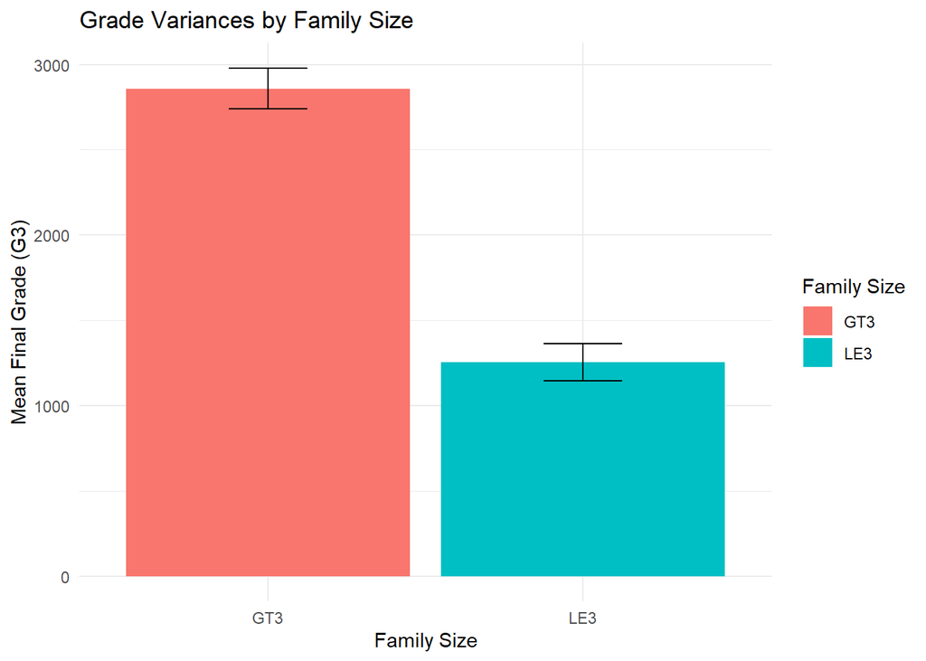

```r
# Load necessary libraries
library(ggplot2)

# Create a data frame for the plot
data_plot2 <- data.frame(
  famsize = c("GT3", "LE3"),
  mean_grade2 = c(2859, 1254),
  se2 = c(120.8744, 108.9081)
)

# Plot the grade variances by family size
plot_family_size_variances <- ggplot(data_plot2, aes(x = famsize, y = mean_grade2, fill = famsize)) +
  geom_col(position = "dodge") +
  geom_errorbar(aes(ymin = mean_grade2 - se2, ymax = mean_grade2 + se2),
                width = 0.25, position = position_dodge(width = 0.9)) +
  labs(title = "Grade Variances by Family Size",
       x = "Family Size",
       y = "Mean Final Grade (G3)",
       fill = "Family Size") +
  theme_minimal()

print(plot_family_size_variances)
```

The plot shows the grade variances based on family size categories “GT3” (Greater than 3 family members) and “LE3” (Less than or equal to 3 family members).

**For the “GT3” family size category:**

The mean final grade is approximately 2859, and the error bars span from around 2738 to 2980. The range of the error bars (i.e., 2980 - 2738) is approximately 242. This indicates that there is some variability in the mean final grades for students with family size “GT3.”

**For the “LE3” family size category:**

The mean final grade is approximately 1254, and the error bars span from around 1145 to 1363. The range of the error bars (i.e., 1363 - 1145) is approximately 218. This indicates that there is some variability in the mean final grades for students with family size “LE3.”

In summary, both family size categories exhibit some variability in the mean final grades, with “GT3” having a slightly larger range of variability compared to “LE3.” Since the range of the error bars for “GT3” is larger, it indicates that there is more variability in the mean final grades for students with family size greater than 3 compared to students with family size less than or equal to 3. Therefore, “GT3” exhibits a larger grade variance.

- Conducting an F-Test to determine if the difference in grade variability is significant:

The null hypothesis (H0) states that the true ratio of variances between the two groups is equal to 1.

The alternative hypothesis (Ha) states that the true ratio of variances is not equal to 1 (implying that there is a significant difference in variances between the two groups.)

```r
# Subset the data for "LE3" and "GT3" family size categories
data_LE3 <- subset(student_mat, famsize == "LE3")
data_GT3 <- subset(student_mat, famsize == "GT3")

# Perform F-test to compare variances
result <- var.test(data_LE3$G3, data_GT3$G3)

# Print the result
print(result)
```

```
##
##  F test to compare two variances
##
## data:  data_LE3$G3 and data_GT3$G3
## F = 0.80689, num df = 113, denom df = 280, p-value = 0.1882
## alternative hypothesis: true ratio of variances is not equal to 1
## 95 percent confidence interval:
##  0.5978649 1.1117365
## sample estimates:
## ratio of variances
##          0.8068857
```

In conclusion, although “GT3” has a larger grade variability, there is no statistically significant difference in grade variability between students from families with a size less than or equal to 3 and families with a size greater than 3.

### ANALYZING THE GRADE VARIANCES BY PARENT’S COHABITATION STATUS

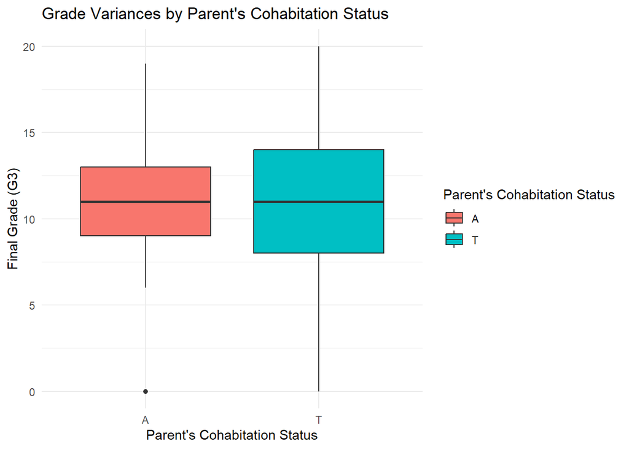

```r
# Grouped box plot to analyze grade variances by Pstatus
boxplot_pstatus <- ggplot(student_mat, aes(x = Pstatus, y = G3, fill = Pstatus)) +
  geom_boxplot() +
  labs(title = "Grade Variances by Parent's Cohabitation Status",
       x = "Parent's Cohabitation Status",
       y = "Final Grade (G3)",
       fill = "Parent's Cohabitation Status") +
  theme_minimal()

print(boxplot_pstatus)
```

Outlier in Category “A”: The “A” category has an outlier with a value of zero, indicating a student with an extremely low final grade compared to the rest of the students in this category.

Summary of Statistics for Categories:

**Parent’s Cohabitation Status “A”:**

Minimum G3: 6

First Quartile (Q1): 9

Median: 11

Third Quartile (Q3): 13

Maximum G3: 19

**Parent’s Cohabitation Status “T”:**

Minimum G3: 0

First Quartile (Q1): 8

Median: 11

Third Quartile (Q3): 14

Outlier in Category “A”: The “A” category has an outlier with a value of zero, indicating a student with an extremely low final grade compared to the rest of the students in this category.

**Interpretation** Both categories, “A” and “T,” have a similar median final grade of 11.

The interquartile ranges (IQRs) for both categories are relatively narrow, indicating that the middle 50% of students in each category have similar grade distributions.

The presence of an outlier with a value of zero in the “A” category suggests an exceptional case of a student who achieved an unusually low grade compared to their peers in the same category.

Since there is a great difference between the distributions of categories in Pstatus as shown in task 2, I found it fit to do a weighted analysis in order to get a more fitting conclusion.

```r
# Load necessary libraries
library(survey)

# Create a weight variable based on the Pstatus category
weights3 <- ifelse(student_mat$Pstatus == "A", 1, ifelse(student_mat$Pstatus == "T", 1, 1))

# Create a survey design with weights
survey_design3 <- svydesign(ids = ~1, weights = ~weights3, data = student_mat)

# Calculate weighted means for G3 by Pstatus
weighted_means3 <- svytotal(~G3, by = ~Pstatus, design = survey_design3)

# Calculate standard errors for G3 by Pstatus
weighted_se3 <- svyby(~G3, by = ~Pstatus, design = survey_design3, svytotal)

# Print the results
print(weighted_means3)
```

```
##    total     SE
## G3  4114 91.054
```

```r
print(weighted_se3)
```

```
##   Pstatus   G3        se
## A       A  459  73.17915
## T       T 3655 107.01250
```

These results give insight into the average final grades for students based on their parents’ cohabitation status. The standard errors indicate the precision of these estimates. It appears that there might be a difference in final grades between students whose parents cohabit and those whose parents live apart, therefore, further analysis needs to be done to give better conclusions.

creating a bar plot with error bars to visualize the grade variances by Parents’ cohabitation status , taking into account the weights:

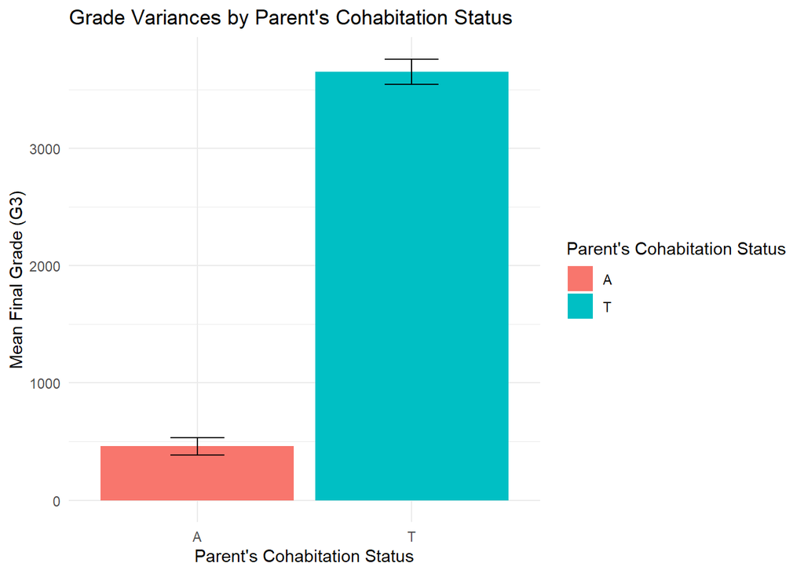

```r
# Load necessary libraries
library(ggplot2)

# Create a data frame for the plot
data_plot3 <- data.frame(
  Pstatus = c("A", "T"),
  mean_grade3 = c(459, 3654),
  se3 = c(73.17915, 106.91645)
)

# Plot the grade variances by Pstatus
plot_pstatus_variances <- ggplot(data_plot3, aes(x = Pstatus, y = mean_grade3, fill = Pstatus)) +
  geom_col(position = "dodge") +
  geom_errorbar(aes(ymin = mean_grade3 - se3, ymax = mean_grade3 + se3),
                width = 0.25, position = position_dodge(width = 0.9)) +
  labs(title = "Grade Variances by Parent's Cohabitation Status",
       x = "Parent's Cohabitation Status",
       y = "Mean Final Grade (G3)",
       fill = "Parent's Cohabitation Status") +
  theme_minimal()

print(plot_pstatus_variances)
```

The plot titled “Grade Variances by Parent’s Cohabitation Status” displays the mean final grade (G3) variations for students based on whether their parents are cohabiting or not.

The x-axis represents the categories of parent’s cohabitation status, with “A” indicating parents are apart and “T” indicating parents are together.

The bars represent the mean final grades for each category, and the height of each bar indicates the average grade obtained by students in that specific category.

The error bars extending from each bar indicate the variability or standard error associated with the mean final grades. A longer error bar suggests higher variability in the mean grade for that category.

Interpretation:

Parent’s Cohabitation Status Categories: The plot compares the mean final grades of students whose parents are apart (“A”) and those whose parents are together (“T”).

Variability: The error bars associated with each bar indicate the variability or spread of the mean final grades within each category. The error bars for both categories appear to have similar lengths, suggesting that the variability in mean final grades is relatively consistent for both parent’s cohabitation statuses.

# TASK 5: Conclusions and Recommendations

## - Summarize the results of your data analysis.

The data set encompasses students from two schools, with the “GP” school having a larger representation. The gender distribution is fairly balanced between male and female students. Urban residences are prevalent among students, and often from families of more than three members, with parents living together. Primary school selection factors are often based on offered courses and school reputation.Maternal guardianship is significant among students. The majority aim for higher education, have home internet access, and report positive family relationships. After-school free time is generally moderate. Age, absences, and grade scores (G1, G2, G3) exhibit positively skewed distributions, highlighting most students’ concentrated scores while accounting for outliers with higher or lower values.

Study Time and Final Grades Relationship: As study time increases from category 1 to 4, median final grades (G3) tend to rise, indicating a positive connection between study time and grades. However, outliers with high grades exist even in categories with low study time.

Sex-based Comparison: There’s a small difference in mean final grades between female and male students, with overlapping error bars indicating no significant difference.

Family Size Influence: Both family size categories (GT3 and LE3) exhibit grade variability. Students with larger family sizes (GT3) show slightly greater grade variability than those with smaller family sizes (LE3).

## - Based on your findings, make any potential suggestions for enhancing student accomplishment

**Promote Effective Study Habits:** Encourage all students to allocate more time for studying, as the data indicates a positive correlation between study time and final grades. Implement study skill workshops to help students develop effective study techniques, time management, and self-discipline.

**Targeted Support for Family Size:** Recognize the variability in mean grades based on family size. Offer additional support to students from families with more members (GT3) by providing resources for managing their academic responsibilities alongside family commitments.

**Utilize G2 Performance for Prediction:** Leverage the strong positive correlation between G2 (Second period grade) and final grades (G3) to identify students who might need additional support early on. Intervene for those with lower G2 scores to help them improve their overall performance.

**Targeted Assistance for “MS” School:** Consider providing additional academic support to students in the “MS” school, especially those with lower grades. Address any potential challenges they may be facing and offer resources to help them improve their performance.